# Codigo Original

```python
#Autora: Adriana Álvarez F.
# Since Collab is being used, it is necessary to install Pytorch
!pip install torch
import torch as torch

import numpy as np
from matplotlib import pyplot as plt
from mpl_toolkits.mplot3d import Axes3D
from matplotlib import cm
```

```python
def sigmoidalActivationFunction(x):
  return (1/(1+(torch.exp(-x))))
```

```python
def forward(weights,featuresT):
  result=weights.mm(featuresT)
  return sigmoidalActivationFunction(result)
```

```python
def countRows(matrix):
  return matrix.size()[0]
```

```python
def countColumns(matrix):
  return matrix.size()[1]
```

```python
# Crea una matriz de tamano countHiddenLayer (rows) x countFeatures (columns)
def randomWeights(rows, colums):
  return (torch.rand(rows, colums))
```

```python
x = torch.tensor([[0.05, 0.01], [0.02, 0.5], [2,4]])
rows=countRows(x) # corresponde a la cantidad de observaciones del dataset, es decir, a la cantidad de observaciones
columns=countColumns(x) #corresponde a la cantidad de features del dataset
countNeuronsHiddenLayer1=1
weights=randomWeights(countNeuronsHiddenLayer1, columns)
#print(weights)
featuresT=x.transpose(0,1)
#print(featuresT)
r = forward(weights,featuresT)
print(r)
```

```
tensor([[0.5045, 0.5715, 0.9403]])
```

# 1)

El resultado de r y por ende lo que imprime la salida de la red neuronal para el conjunto de características de entrada x, basicamente una matriz de dimensiones 1x3, donde cada elemento representa la salida de la red neuronal para una observación en el conjunto de datos de entrada

# 2)

Si se agrega una observación adicional al dataset, esto implica agregar una fila adicional a la matriz de características de entrada x. El resultado en r se verá afectado, ya que se realizará el cálculo de la salida de la red neuronal considerando la nueva observación. Al agregar una nueva observación a x, la matriz de características de entrada se actualiza para tener una dimensión de 4x2, lo que significa que ahora hay 4 observaciones en el conjunto de datos y 2 características para cada observación. Luego, se realiza el cálculo de la salida de la red neuronal utilizando la función forward con el nuevo dataset modificado.

```python
# Se agrega una observación adicional al dataset
x = torch.tensor([[0.05, 0.01], [0.02, 0.5], [2,4], [0.1, 0.3]])
rows = countRows(x) # corresponde a la cantidad de observaciones del dataset, es decir, a la cantidad de observaciones
columns = countColumns(x) # corresponde a la cantidad de features del dataset

# Imprimir el nuevo dataset modificado
print("Dataset modificado:")
print(x)

# Calcular la salida de la red neuronal con el nuevo dataset
featuresT = x.transpose(0,1)
r = forward(weights, featuresT)

# Imprimir el resultado en r
print("Resultado en r:")
print(r)
```

```
Dataset modificado:
tensor([[0.0500, 0.0100],
        [0.0200, 0.5000],
        [2.0000, 4.0000],
        [0.1000, 0.3000]])
Resultado en r:
tensor([[0.5045, 0.5715, 0.9403, 0.5485]])
```

# 3)

Si se agrega una característica adicional al dataset, esto significa que hay agregar una columna adicional a la matriz de características de entrada x. El resultado en r se verá afectado, ya que ahora se considerará esta nueva característica en el cálculo de la salida de la red neuronal.

```python
# Se agrega una característica adicional al dataset
x = torch.tensor([[0.05, 0.01, 0.1], [0.02, 0.5, 0.3], [2, 4, 1]])
rows = countRows(x) # corresponde a la cantidad de observaciones del dataset, es decir, a la cantidad de observaciones
columns = countColumns(x) # corresponde a la cantidad de características del dataset

# Crea una nueva matriz de pesos compatible con la nueva dimensión de características
countNeuronsHiddenLayer1 = 1
weights = randomWeights(countNeuronsHiddenLayer1, columns)

# Imprimir el nuevo dataset modificado
print("Dataset modificado:")
print(x)

# Calcular la salida de la red neuronal con el nuevo dataset
featuresT = x.transpose(0, 1)
r = forward(weights, featuresT)

# Imprimir el resultado en r
print("Resultado en r:")
print(r)
```

```
Dataset modificado:
tensor([[0.0500, 0.0100, 0.1000],
        [0.0200, 0.5000, 0.3000],
        [2.0000, 4.0000, 1.0000]])
Resultado en r:
tensor([[0.5341, 0.6681, 0.9978]])
```

# 4)

Para modificar el codigo se puede agregar una nueva neurona a la capa oculta 1 y se define countNeuronsHiddenLayer1 con el valor de 2. Luego, se generan pesos aleatorios para la nueva neurona mediante la función randomWeights. Y asi finalmente, se realiza el cálculo hacia adelante y se muestra el resultado en r.

```
Resultado en r:
tensor([[0.5362, 0.6765, 0.9974],
        [0.5108, 0.5953, 0.9760]])
```

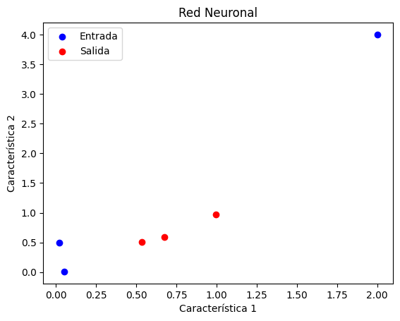

```python
import torch
from matplotlib import pyplot as plt

def sigmoidalActivationFunction(x):
  return 1 / (1 + torch.exp(-x))

def forward(weights, featuresT):
  result = weights.mm(featuresT)
  return sigmoidalActivationFunction(result)

x = torch.tensor([[0.05, 0.01, 0.1], [0.02, 0.5, 0.3], [2, 4, 1]])
weights = torch.rand(2, 3)  # Agregar una nueva neurona a la capa oculta 1
featuresT = x.transpose(0, 1)
r = forward(weights, featuresT)

# Imprimir el resultado en r
print("Resultado en r:")
print(r)

# Dibujar la red neuronal
plt.scatter(x[:, 0], x[:, 1], color='blue', label='Entrada')
plt.scatter(r[0], r[1], color='red', label='Salida')
plt.xlabel('Característica 1')
plt.ylabel('Característica 2')
plt.title('Red Neuronal')
plt.legend()
plt.show()
```

# 5)

En este punto, se agregó un parámetro adicional llamado bias en la función forward(). El sesgo (bias) se suma a la matriz de pesos multiplicada por las características transpuestas en el cálculo del resultado.

```python
import torch
import numpy as np
from matplotlib import pyplot as plt
from mpl_toolkits.mplot3d import Axes3D
from matplotlib import cm

def sigmoidalActivationFunction(x):
  return 1 / (1 + torch.exp(-x))

def forward(weights, featuresT, bias):
  result = weights.mm(featuresT) + bias
  return sigmoidalActivationFunction(result)

def countRows(matrix):
  return matrix.size()[0]

def randomWeights(rows, columns):
  return torch.rand(rows, columns)

x = torch.tensor([[0.05, 0.01], [0.02, 0.5], [2, 4]])
rows = countRows(x)
columns = x.size()[1]
countNeuronsHiddenLayer1 = 1

weights = randomWeights(countNeuronsHiddenLayer1, columns)
bias = torch.tensor([[0.5]])  # Definir el valor del bias

featuresT = x.transpose(0, 1)

r = forward(weights, featuresT, bias)
print(r)
```

```
tensor([[0.6345, 0.7135, 0.9956]])
```

# 6)

El gráfico generado muestra los puntos de entrada (x) y se colorea según la salida de la red neuronal con capa oculta 2. Cada punto en el gráfico representa una observación y su posición se determina por las dos características de entrada.

```
tensor([[0.5590, 0.5600, 0.5724]])
```

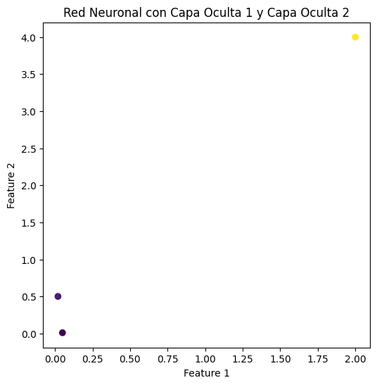

```python
import torch
import numpy as np
from matplotlib import pyplot as plt
from mpl_toolkits.mplot3d import Axes3D
from matplotlib import cm

def sigmoidalActivationFunction(x):
    return 1 / (1 + torch.exp(-x))

def forward(weights1, weights2, featuresT, bias1, bias2):
    hidden1 = sigmoidalActivationFunction(weights1.mm(featuresT) + bias1)
    hidden2 = sigmoidalActivationFunction(weights2.mm(hidden1) + bias2)
    return hidden2

def countRows(matrix):
    return matrix.size()[0]

def randomWeights(rows, columns):
    return torch.rand(rows, columns)

x = torch.tensor([[0.05, 0.01], [0.02, 0.5], [2, 4]])
rows = countRows(x)
columns = x.size()[1]
countNeuronsHiddenLayer1 = 2
countNeuronsHiddenLayer2 = 1

weights1 = randomWeights(countNeuronsHiddenLayer1, columns)
weights2 = randomWeights(countNeuronsHiddenLayer2, countNeuronsHiddenLayer1)
bias1 = torch.tensor([[0.5], [0.2]])  # Definir el valor del bias para la capa oculta 1
bias2 = torch.tensor([[0.1]])  # Definir el valor del bias para la capa oculta 2

featuresT = x.transpose(0, 1)

output = forward(weights1, weights2, featuresT, bias1, bias2)
print(output)

# Dibujar la red neuronal
plt.figure(figsize=(6, 6))
plt.scatter(x[:, 0], x[:, 1], c=output.view(-1))
plt.xlabel('Feature 1')
plt.ylabel('Feature 2')
plt.title('Red Neuronal con Capa Oculta 1 y Capa Oculta 2')
plt.show()
```

# 7)

De esta manera, el código ha sido modificado para agregar una nueva neurona a la capa oculta 2, y el gráfico resultante mostrará la salida de la red neuronal actualizada.

```
tensor([[0.7297, 0.7310, 0.7381]])
```

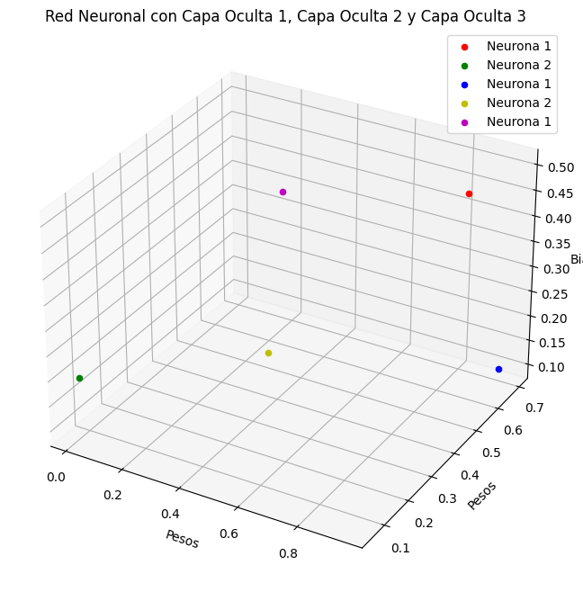

```python
import torch
import numpy as np
from matplotlib import pyplot as plt
from mpl_toolkits.mplot3d import Axes3D
from matplotlib import cm

def sigmoidalActivationFunction(x):
    return 1 / (1 + torch.exp(-x))

def forward(weights1, weights2, weights3, featuresT, bias1, bias2, bias3):
    hidden1 = sigmoidalActivationFunction(weights1.mm(featuresT) + bias1)
    hidden2 = sigmoidalActivationFunction(weights2.mm(hidden1) + bias2)
    hidden3 = sigmoidalActivationFunction(weights3.mm(hidden2) + bias3)
    return hidden3

def countRows(matrix):
    return matrix.size()[0]

def randomWeights(rows, columns):
    return torch.rand(rows, columns)

x = torch.tensor([[0.05, 0.01], [0.02, 0.5], [2, 4]])
rows = countRows(x)
columns = x.size()[1]
countNeuronsHiddenLayer1 = 2
countNeuronsHiddenLayer2 = 2

weights1 = randomWeights(countNeuronsHiddenLayer1, columns)
weights2 = randomWeights(countNeuronsHiddenLayer2, countNeuronsHiddenLayer1)
weights3 = randomWeights(1, countNeuronsHiddenLayer2)
bias1 = torch.tensor([[0.5], [0.2]])  # Definir el valor del bias para la capa oculta 1
bias2 = torch.tensor([[0.1], [0.3]])  # Definir el valor del bias para la capa oculta 2
bias3 = torch.tensor([[0.4]])  # Definir el valor del bias para la capa oculta 3

featuresT = x.transpose(0, 1)

output = forward(weights1, weights2, weights3, featuresT, bias1, bias2, bias3)
print(output)

# Dibujar la red neuronal
fig = plt.figure(figsize=(8, 8))
ax = fig.add_subplot(111, projection='3d')

# Capa oculta 1
ax.scatter(weights1[0, 0], weights1[0, 1], bias1[0], color='r', label='Neurona 1')
ax.scatter(weights1[1, 0], weights1[1, 1], bias1[1], color='g', label='Neurona 2')

# Capa oculta 2
ax.scatter(weights2[0, 0], weights2[0, 1], bias2[0], color='b', label='Neurona 1')
ax.scatter(weights2[1, 0], weights2[1, 1], bias2[1], color='y', label='Neurona 2')

# Capa oculta 3
ax.scatter(weights3[0, 0], weights3[0, 1], bias3[0], color='m', label='Neurona 1')

ax.set_xlabel('Pesos')
ax.set_ylabel('Pesos')
ax.set_zlabel('Bias')
ax.set_title('Red Neuronal con Capa Oculta 1, Capa Oculta 2 y Capa Oculta 3')
ax.legend()

plt.show()
```

# 8)

En esta versión del código, se ha eliminado la función countRows ya que se puede utilizar directamente x.shape para obtener el número de filas y columnas de la matriz de entrada x.

Además, se ha reemplazado las operaciones mm por torch.matmul para realizar las multiplicaciones de matrices.

La inicialización de los pesos y sesgos se realiza mediante las funciones randomWeights e initializeBias, respectivamente, para generar valores aleatorios y ceros.

Finalmente, el resultado se transpone para que tenga la forma correcta y se muestra el gráfico de la red neuronal utilizando plt.scatter.

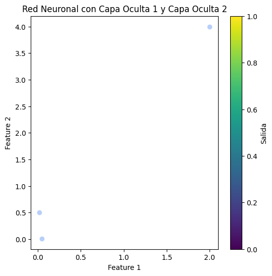

```python
import torch
import numpy as np
from matplotlib import pyplot as plt
from matplotlib import cm

def sigmoidalActivationFunction(x):
    return 1 / (1 + torch.exp(-x))

def forward(weights1, weights2, featuresT, bias1, bias2):
    hidden1 = sigmoidalActivationFunction(torch.matmul(weights1, featuresT) + bias1)
    hidden2 = sigmoidalActivationFunction(torch.matmul(weights2, hidden1) + bias2)
    return hidden2

def randomWeights(rows, columns):
    return torch.rand(rows, columns)

def initializeBias(rows):
    return torch.zeros(rows, 1)

# Parámetros de la red neuronal
numObservations = 3
numFeatures = 2
countNeuronsHiddenLayer1 = 2
countNeuronsHiddenLayer2 = 2

# Datos de entrada
x = torch.tensor([[0.05, 0.01], [0.02, 0.5], [2, 4]])
rows, columns = x.shape

# Generar pesos aleatorios y sesgos
weights1 = randomWeights(countNeuronsHiddenLayer1, numFeatures)
weights2 = randomWeights(countNeuronsHiddenLayer2, countNeuronsHiddenLayer1)
bias1 = initializeBias(countNeuronsHiddenLayer1)
bias2 = initializeBias(countNeuronsHiddenLayer2)

# Transponer las características
featuresT = x.transpose(0, 1)

# Calcular la salida de la red neuronal
hidden1 = sigmoidalActivationFunction(torch.matmul(weights1, featuresT) + bias1)
hidden2 = sigmoidalActivationFunction(torch.matmul(weights2, hidden1) + bias2)

output = hidden2[:2].transpose(0, 1)  # Utilizar solo las primeras dos columnas de la salida
output_np = output.detach().numpy()  # Convertir a un arreglo NumPy

# Mapear los valores de salida a un solo color utilizando el mapa de colores
norm = plt.Normalize(output_np.min(), output_np.max())
color = cm.coolwarm(norm(output_np.mean()))

# Dibujar la red neuronal
plt.figure(figsize=(6, 6))
plt.scatter(x[:, 0], x[:, 1], color=color)
plt.xlabel('Feature 1')
plt.ylabel('Feature 2')
plt.title('Red Neuronal con Capa Oculta 1 y Capa Oculta 2')
plt.colorbar(label='Salida')
plt.show()
```

# 9)

En este código, se ha agregado el tensor target, que contiene los valores objetivo correspondientes a cada observación en el conjunto de datos. Luego, se ha definido la función calculateError, que calcula el error como la diferencia entre el objetivo y la salida de la red neuronal.

Después de obtener la salida (output) de la función forward, se calcula el error llamando a la función calculateError y pasando el resultado de la salida y el tensor target. Finalmente, se imprime la salida y el error.

```python
import torch

def sigmoidalActivationFunction(x):
    return 1 / (1 + torch.exp(-x))

def forward(weights, featuresT):
    result = weights.mm(featuresT)
    return sigmoidalActivationFunction(result)

def calculateError(output, target):
    error = target - output
    return error

x = torch.tensor([[0.05, 0.01], [0.02, 0.5], [2, 4]])
target = torch.tensor([0, 1, 1])

countNeuronsHiddenLayer1 = 1
weights = torch.rand(countNeuronsHiddenLayer1, x.size()[1])
featuresT = x.transpose(0, 1)

output = forward(weights, featuresT)
error = calculateError(output, target)

print("Output:", output)
print("Error:", error)
```

```
Output: tensor([[0.5028, 0.5888, 0.9539]])
Error: tensor([[-0.5028,  0.4112,  0.0461]])
```